# M8_Entrega_final

- Construir un modelo **SARIMA** que se ajuste de la mejor forma posible a la serie temporal.
- Construir un **algoritmo de optimización** basado en simulated annealing, para elegir los mejores parámetros de un modelo.
- Construir un **grafo** con todas las soluciones que permita elegir vecinos de forma aleatoria.

```python
#Importamos las librerías necesarias
import numpy as np
import pandas as pd
from pmdarima.arima import nsdiffs #nsdiffs obtiene el valor D, que indica si existe estacionalidad
from statsmodels.tsa.stattools import adfuller #adfuller indica si la serie es estacionaria
from statsmodels.tsa.seasonal import seasonal_decompose
from matplotlib import pyplot
import statsmodels.api as sm
import networkx as nx
import itertools #para que los bucles sean más eficientes
from  statsmodels.tsa.statespace.sarimax import SARIMAX
import random
import math
from sklearn.metrics import mean_squared_error
from statsmodels.stats.diagnostic import acorr_ljungbox
```

Comenzamos estableciendo el índice con las fechas y mostrando la gráfica con los datos de la serie:

```python
#Leemos el csv con los datos
electric_prod = ( pd.read_csv("Electric_Production.csv")
    .assign(date=lambda x:pd.to_datetime(x.DATE))
    .set_index("date")
    .drop(columns=["DATE"])
    .fillna(0)
)
electric_prod
```

| date | IPG2211A2N |
| --- | --- |
| 1985-01-01 | 72.5052 |
| 1985-02-01 | 70.6720 |
| 1985-03-01 | 62.4502 |
| 1985-04-01 | 57.4714 |
| 1985-05-01 | 55.3151 |
| ... | ... |
| 2017-09-01 | 98.6154 |
| 2017-10-01 | 93.6137 |
| 2017-11-01 | 97.3359 |
| 2017-12-01 | 114.7212 |
| 2018-01-01 | 129.4048 |

397 rows × 1 columns

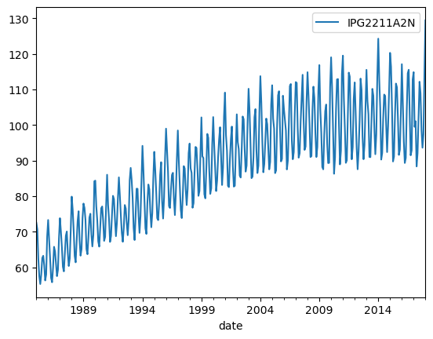

```python
electric_prod.plot()
```

Para ver mejor los componentes de la serie, la descomponemos:

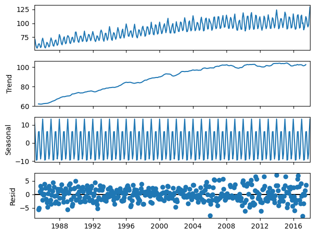

```python
result = seasonal_decompose(electric_prod, model='additive')
result.plot()
pyplot.show()
```

Se dividen los datos en dos grupos, el de test (50 últimas filas) y el de entrenamiento:

```python
test_cases = 50
data_training = electric_prod.iloc[:-test_cases,:]
data_test = electric_prod.iloc[-test_cases:,:]
m = 12  #Se toman 12 muestras anuales
```

**Fase de identificación:**

```python
# Calculamos D
D = nsdiffs(data_training.IPG2211A2N, m=m)
print(f'{D=}')
```

```
D=0
```

Como **D=0**, no existe estacionalidad significativa en la serie.

Es decir, se usará un modelo **ARIMA** en vez del SARIMA mencionado en el enunciado

El siguiente paso será comprobar si la serie es estacionaria:

```python
test_results = adfuller(data_training.IPG2211A2N)
print(f"adf statistics value: {test_results[0]} - p_value: {test_results[1]}")
```

```
adf statistics value: -2.2110757549374584 - p_value: 0.20225018352084695
```

Como p_value está por encima de 0.05, la serie no es estacionaria.

Para que sea estacionaria, se deriva (**d=1**) hasta obtener un valor de p < 0.05

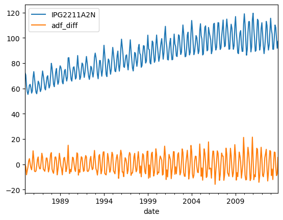

```python
data_training = ( data_training
    .assign(adf_diff=lambda x: x.IPG2211A2N.diff(1).fillna(0))
)
data_training.plot()
```

```python
test_results = adfuller(data_training.adf_diff)
print(f"adf statistics value: {test_results[0]} - p_value: {test_results[1]}")
```

```
adf statistics value: -6.690777828536012 - p_value: 4.114981382432929e-09
```

Para la solución inicial, buscamos valores adecuados en los gráficos de autocorrelación:

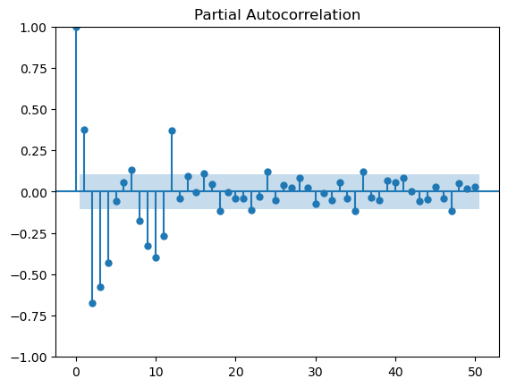

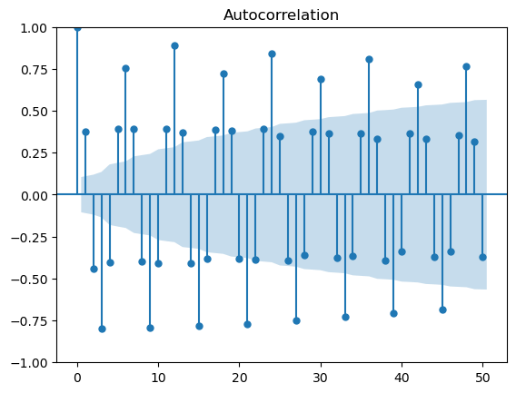

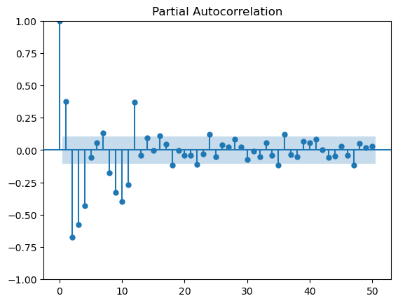

```python
sm.graphics.tsa.plot_acf(data_training.adf_diff,lags=50)
sm.graphics.tsa.plot_pacf(data_training.adf_diff,lags=50)
```

Como se puede observar en el gráfico de autocorrelación, la serie temporal tiene cierta estacionalidad. Es decir, podría tratarse de una estacionalidad débil o no lineal y por lo tanto haber sido ignorada en nsdiffs.

Por ahora, vamos a suponer que D>0 y aplicar diferenciación estacional para ver si mejora el comportamiento.

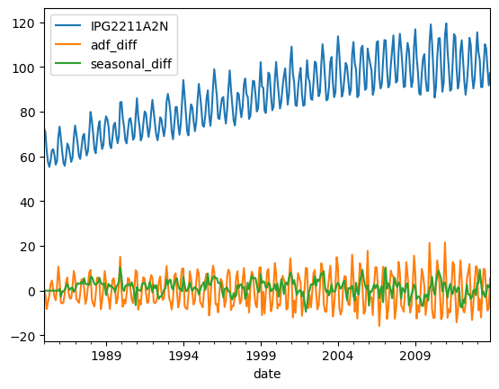

```python
D = 1
data_training = ( data_training
    .assign(seasonal_diff=lambda x: x.IPG2211A2N.diff(m*D).fillna(0))
)
data_training.plot()
```

```python
test_results = adfuller(data_training.seasonal_diff)
print(f"adf statistics value: {test_results[0]} - p_value: {test_results[1]}")
```

```
adf statistics value: -5.799144549555005 - p_value: 4.675231353770225e-07
```

Como p < 0.05, es estacional (**d=0**).

Volvemos a mostrar las gráficas para ver si ya no hay estacionalidad:

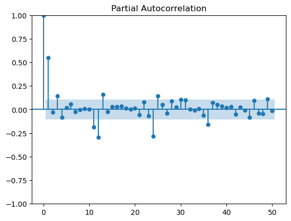

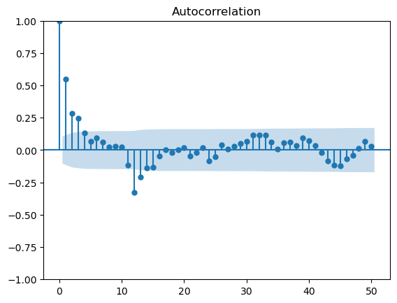

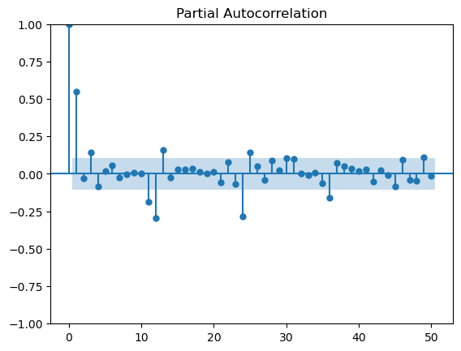

```python
sm.graphics.tsa.plot_acf(data_training.seasonal_diff,lags=50)
sm.graphics.tsa.plot_pacf(data_training.seasonal_diff,lags=50)
```

Podemos observar lo siguiente:

- La autocorrelación decae de foma exponencial suavizada.
- La autocorrelación parcial tiene una caída más brusca a partir de lag 2. Es decir, p=2 y q=2 (valores estimados para la solución inicial)

Además, ambas gráficas tienen picos significativos en el lag 12: P=1, Q=1

El modelo inicial sería **SARIMA(p=2,d=0,q=2)(P=1,D=1,Q=1)(m=12)**

```python
# D ya tiene asignado su valor
p = 2
q = 2
d = 0
P = 1
Q = 1
```

Creamos un **grafo** con todas las posibles configuraciones de los parámetros:

```python
lim_param = {
    'p':(0, 7), #todos los parámetros deben ser >=0 y <8 (p, q, P, Q)
    'd':(0, 2), #el valor debería ser solo +/-1 sobre la solución inicial, pero como antes de quitar la estacionalidad el valor de d era 1, mejor tener un rango de tres valores (0, 1 y 2)
    'q':(0, 7),
    'P':(0, 7),
    'D':(1, 2), #D=1, en la solución inicial
    'Q':(0, 7)
}

def generar_nodos():  #Para generar todos los nodos posibles
    p_range = range(0,8)
    d_range = range(0,3)
    q_range = range(0,8)
    P_range = range(0,8)
    D_range = range(1,3)
    Q_range = range(0,8)

    #Para hacer más eficiente la función y evitar el uso excesivo de bucles for, se usa itertools.product.
    #itertools.product es el producto cartesiano, consiguiendo así todas las combinaciones de parámetros posibles.
    nodos = list(itertools.product(p_range, d_range, q_range, P_range, D_range, Q_range))
    return nodos

def generar_vecinos(nodo):
    vecinos = [] #lista de tuplas con los vecinos del nodo
    for i, param in enumerate(['p', 'd', 'q', 'P', 'D', 'Q']):
        for incr in [-1, 1]: #los vecinos cambian en +/-1 el valor de los parámetros
            param_modificado = nodo[i] + incr
            if lim_param[param][0] <= param_modificado <= lim_param[param][1]: #si está dentro del rango de soluciones válidas, añadir el vecino
                vecino = list(nodo) #lo volvemos una lista para modificar el parámetro
                vecino[i] = param_modificado
                vecinos.append(tuple(vecino))
    return vecinos
```

```python
G = nx.Graph()
nodos = generar_nodos()
G.add_nodes_from(nodos) #Añadimos los nodos al grafo
print(G.number_of_nodes())
```

```
24576
```

```python
for n in nodos:
    vecinos = generar_vecinos(n)
    for vecino in vecinos:
        if vecino in nodos: #el vecino debe estar entre los nodos del grafo
            G.add_edge(n, vecino)

print(G.number_of_edges())
```

```
114688
```

Para comprobar si el grafo se ha creado sin problemas:

```python
nodo_inicial= (2,0,2,1,1,1)
print(f'Vecinos de {nodo_inicial}: {list(G.neighbors(nodo_inicial))}')
```

```
Vecinos de (2, 0, 2, 1, 1, 1): [(1, 0, 2, 1, 1, 1), (2, 0, 1, 1, 1, 1), (2, 0, 2, 0, 1, 1), (2, 0, 2, 1, 1, 0), (3, 0, 2, 1, 1, 1), (2, 1, 2, 1, 1, 1), (2, 0, 3, 1, 1, 1), (2, 0, 2, 2, 1, 1), (2, 0, 2, 1, 2, 1), (2, 0, 2, 1, 1, 2)]
```

[figure not shown]

```python
fig, ax = pyplot.subplots(figsize=(15, 9))
ax.axis("off")
plot_options = {"node_size": 10, "with_labels": False, "width": 0.1}

pos=nx.random_layout(G)
nx.draw_networkx(G, pos=pos, ax=ax, **plot_options)
```

Antes de empezar el algoritmo de optimización, se va a seleccionar la segunda solución inicial (la primera se obtuvo mediante conocimiento experto: (2,0,2,1,1,1))

```python
closs = nx.closeness_centrality(G)
closs_ordenado = sorted(closs.items(), key=lambda x: x[1])
nodo_inicial_2 = closs_ordenado[0][0]
print(f"{nodo_inicial_2}")
```

```
(0, 0, 0, 0, 1, 0)
```

**Fase de estimación:**

Comenzamos creando una función para calcular el **RMSE** (Root Mean Squared Error) de un modelo SARIMA

```python
def evaluar_sarima(d_train, d_test, order, order_s): #order: (p,d,q) order_s: (P,D,Q,m)
    try:
        model = SARIMAX(d_train, order=order, seasonal_order=order_s)
        res = model.fit(disp=0) #para evitar salida innecesaria de código
        predicted_value = res.forecast(steps=len(d_test)) #pronóstico 50 pasos hacia adelante (tamaño del data_test)
        #MSE: Error Cuadrático Medio entre los valores reales (test_data) y los pronosticados (predicted_value)
        #Para obtener el RMSE, solo falta aplicar la raíz cuadrada sobre el cálculo anterior
        rmse = np.sqrt(mean_squared_error(d_test, predicted_value))

        residuos = res.resid
        resid_test = acorr_ljungbox(residuos, lags=6, return_df=True)
        p_values = resid_test["lb_pvalue"].values  # Extraer los p-values del test
        if any(p_value < 0.05 for p_value in p_values):
            print("Residuos autocorrelacionados")
            return float(80)  # Asignar un valor alto de RMSE
        return rmse
    except Exception as e:
        print(f"Error en evaluar_sarima: {e}")
        return float('inf') #si el modelo no converge, devolver inf
```

Algoritmo de **simulated_annealing**:

```python
def simulated_annealing(d_train, d_test, n_ini, G, max_iter=30, temp_ini=10):
    #inicializamos las variables y obtenemos el rmse de la solución inicial
    n_actual = n_ini
    rmse_actual = evaluar_sarima(d_train, d_test, n_actual[:3], (n_actual[3], n_actual[4], n_actual[5], m))
    mejor_n = n_actual
    mejor_rmse = rmse_actual
    #T = temp_ini

    for i in range(max_iter):
        #La temperatura se puede reducir de dos formas:
        #  -de forma exponencial (convergencia más rápida)
        #  -de forma lineal (más tiempo explorando)
        #T *= 0.9 #(forma exponencial)
        T = temp_ini / (i+1)  #Se reduce la temperatura (forma lineal)
        #Se genera un nuevo vecino al azar, consultando el grafo
        vecinos = list(G.neighbors(n_actual))
        vecino = tuple(random.choice(vecinos))
        rmse_vecino = evaluar_sarima(d_train, d_test, vecino[:3], (vecino[3], vecino[4], vecino[5], m))

        #-si el vecino es mejor que el nodo actual, aceptarlo
        #-si el vecino es peor, aceptarlo con una probabilidad que depende de T y la diferencia en la métrica
            # np.random.rand() genera un número aleatorio entre 0 y 1. Si es menor que la probabilidad de aceptación, se acepta la solución peor (la del vecino)
            # probabilidad de aceptación:
                #se calcula la diferencia entre los rmse y se divide por la temperatura actual. El resultado será el exponente de 'e'
                #el exponente es negativo para que el valor de la probabilidad sea elevado cuando las soluciones tienen poca diferencia entre sí.
        if rmse_vecino < rmse_actual or (np.random.rand() < np.exp((-(rmse_actual - rmse_vecino))/T)):
            n_actual = vecino
            rmse_actual = rmse_vecino
        if rmse_actual < mejor_rmse:
            mejor_n = n_actual
            mejor_rmse = rmse_actual

        print(f"Iteración {i+1}: Nodo actual={n_actual}, RMSE={rmse_actual}, Mejor RMSE={mejor_rmse}")
    return mejor_n, mejor_rmse
```

```python
mejor_sol, mejor_rmse = simulated_annealing(data_training.IPG2211A2N, data_test.IPG2211A2N, nodo_inicial, G)
print(f"Mejor solución: {mejor_sol}")
print(f"RMSE: {mejor_rmse}")
```

```
Residuos autocorrelacionados
```

```
Residuos autocorrelacionados
Iteración 1: Nodo actual=(1, 0, 2, 1, 1, 1), RMSE=80.0, Mejor RMSE=80.0
```

```
Residuos autocorrelacionados
Iteración 2: Nodo actual=(1, 0, 2, 1, 1, 2), RMSE=80.0, Mejor RMSE=80.0
```

```
Residuos autocorrelacionados
Iteración 3: Nodo actual=(2, 0, 2, 1, 1, 2), RMSE=80.0, Mejor RMSE=80.0
```

```
Residuos autocorrelacionados
Iteración 4: Nodo actual=(2, 0, 2, 1, 2, 2), RMSE=80.0, Mejor RMSE=80.0
```

```
Residuos autocorrelacionados
Iteración 5: Nodo actual=(1, 0, 2, 1, 2, 2), RMSE=80.0, Mejor RMSE=80.0
```

```
Residuos autocorrelacionados
Iteración 6: Nodo actual=(1, 0, 1, 1, 2, 2), RMSE=80.0, Mejor RMSE=80.0
```

```
Residuos autocorrelacionados
Iteración 7: Nodo actual=(1, 0, 1, 1, 2, 3), RMSE=80.0, Mejor RMSE=80.0
```

```
Iteración 8: Nodo actual=(1, 1, 1, 1, 2, 3), RMSE=3.6177577074194245, Mejor RMSE=3.6177577074194245
```

```
Iteración 9: Nodo actual=(2, 1, 1, 1, 2, 3), RMSE=3.6286371836334403, Mejor RMSE=3.6177577074194245
```

```
Iteración 10: Nodo actual=(2, 1, 1, 2, 2, 3), RMSE=3.5997132930234685, Mejor RMSE=3.5997132930234685
```

```
Iteración 11: Nodo actual=(2, 1, 1, 2, 1, 3), RMSE=3.4629724102283483, Mejor RMSE=3.4629724102283483
```

```
Iteración 12: Nodo actual=(2, 1, 0, 2, 1, 3), RMSE=4.558019376674696, Mejor RMSE=3.4629724102283483
```

```
Iteración 13: Nodo actual=(2, 1, 0, 2, 2, 3), RMSE=5.247765859800207, Mejor RMSE=3.4629724102283483
```

```
Iteración 14: Nodo actual=(2, 1, 0, 3, 2, 3), RMSE=5.153439687341824, Mejor RMSE=3.4629724102283483
```

```
Iteración 15: Nodo actual=(3, 1, 0, 3, 2, 3), RMSE=4.575696397979285, Mejor RMSE=3.4629724102283483
```

```
Iteración 16: Nodo actual=(3, 1, 1, 3, 2, 3), RMSE=3.546597312623574, Mejor RMSE=3.4629724102283483
```

```
Iteración 17: Nodo actual=(3, 1, 1, 2, 2, 3), RMSE=3.587751337716495, Mejor RMSE=3.4629724102283483
```

```
Iteración 18: Nodo actual=(3, 1, 1, 3, 2, 3), RMSE=3.546597312623574, Mejor RMSE=3.4629724102283483
```

```
Iteración 19: Nodo actual=(3, 1, 1, 3, 2, 2), RMSE=3.53504541738174, Mejor RMSE=3.4629724102283483
```

```
Residuos autocorrelacionados
Iteración 20: Nodo actual=(3, 2, 1, 3, 2, 2), RMSE=80.0, Mejor RMSE=3.4629724102283483
```

```
Iteración 21: Nodo actual=(3, 1, 1, 3, 2, 2), RMSE=3.53504541738174, Mejor RMSE=3.4629724102283483
```

```
Iteración 22: Nodo actual=(3, 1, 2, 3, 2, 2), RMSE=3.5729162541697415, Mejor RMSE=3.4629724102283483
```

```
Iteración 23: Nodo actual=(4, 1, 2, 3, 2, 2), RMSE=3.6062902633681717, Mejor RMSE=3.4629724102283483
```

```
Residuos autocorrelacionados
Iteración 24: Nodo actual=(4, 2, 2, 3, 2, 2), RMSE=80.0, Mejor RMSE=3.4629724102283483
```

```
Residuos autocorrelacionados
Iteración 25: Nodo actual=(4, 2, 2, 2, 2, 2), RMSE=80.0, Mejor RMSE=3.4629724102283483
```

```
Residuos autocorrelacionados
Iteración 26: Nodo actual=(4, 2, 2, 2, 2, 1), RMSE=80.0, Mejor RMSE=3.4629724102283483
```

```
Residuos autocorrelacionados
Iteración 27: Nodo actual=(4, 2, 2, 2, 1, 1), RMSE=80.0, Mejor RMSE=3.4629724102283483
```

```
Residuos autocorrelacionados
Iteración 28: Nodo actual=(3, 2, 2, 2, 1, 1), RMSE=80.0, Mejor RMSE=3.4629724102283483
```

```
Residuos autocorrelacionados
Iteración 29: Nodo actual=(3, 2, 2, 1, 1, 1), RMSE=80.0, Mejor RMSE=3.4629724102283483
```

```
Residuos autocorrelacionados
Iteración 30: Nodo actual=(3, 2, 2, 2, 1, 1), RMSE=80.0, Mejor RMSE=3.4629724102283483
Mejor solución: (2, 1, 1, 2, 1, 3)
RMSE: 3.4629724102283483
```

La mejor solución, usando como nodo inicial el obtenido mediante conocimiento experto (2,0,2)(1,1,1), es **(2,1,1)(2,1,3)**, con un **RMSE de 3.4629**

Repetimos la ejecución pero usando el otro nodo inicial:

```python
mejor_sol, mejor_rmse = simulated_annealing(data_training.IPG2211A2N, data_test.IPG2211A2N, nodo_inicial_2, G)
print(f"Mejor solución: {mejor_sol}")
print(f"RMSE: {mejor_rmse}")
```

```
Residuos autocorrelacionados
Residuos autocorrelacionados
Iteración 1: Nodo actual=(0, 0, 0, 0, 2, 0), RMSE=80.0, Mejor RMSE=80.0
Residuos autocorrelacionados
Iteración 2: Nodo actual=(0, 0, 0, 1, 2, 0), RMSE=80.0, Mejor RMSE=80.0
Residuos autocorrelacionados
Iteración 3: Nodo actual=(0, 0, 0, 1, 1, 0), RMSE=80.0, Mejor RMSE=80.0
```

```
Residuos autocorrelacionados
Iteración 4: Nodo actual=(0, 0, 1, 1, 1, 0), RMSE=80.0, Mejor RMSE=80.0
Residuos autocorrelacionados
Iteración 5: Nodo actual=(0, 0, 1, 0, 1, 0), RMSE=80.0, Mejor RMSE=80.0
```

```
Residuos autocorrelacionados
Iteración 6: Nodo actual=(0, 0, 2, 0, 1, 0), RMSE=80.0, Mejor RMSE=80.0
Residuos autocorrelacionados
Iteración 7: Nodo actual=(0, 0, 2, 1, 1, 0), RMSE=80.0, Mejor RMSE=80.0
```

```
Residuos autocorrelacionados
Iteración 8: Nodo actual=(0, 0, 2, 0, 1, 0), RMSE=80.0, Mejor RMSE=80.0
Residuos autocorrelacionados
Iteración 9: Nodo actual=(0, 0, 2, 1, 1, 0), RMSE=80.0, Mejor RMSE=80.0
```

```
Residuos autocorrelacionados
Iteración 10: Nodo actual=(0, 0, 1, 1, 1, 0), RMSE=80.0, Mejor RMSE=80.0
Residuos autocorrelacionados
Iteración 11: Nodo actual=(0, 0, 1, 0, 1, 0), RMSE=80.0, Mejor RMSE=80.0
```

```
Residuos autocorrelacionados
Iteración 12: Nodo actual=(0, 0, 2, 0, 1, 0), RMSE=80.0, Mejor RMSE=80.0
Residuos autocorrelacionados
Iteración 13: Nodo actual=(0, 0, 1, 0, 1, 0), RMSE=80.0, Mejor RMSE=80.0
```

```
Residuos autocorrelacionados
Iteración 14: Nodo actual=(0, 0, 1, 0, 1, 1), RMSE=80.0, Mejor RMSE=80.0
```

```
Residuos autocorrelacionados
Iteración 15: Nodo actual=(0, 0, 1, 0, 2, 1), RMSE=80.0, Mejor RMSE=80.0
```

```
Residuos autocorrelacionados
Iteración 16: Nodo actual=(1, 0, 1, 0, 2, 1), RMSE=80.0, Mejor RMSE=80.0
```

```
Residuos autocorrelacionados
Iteración 17: Nodo actual=(1, 0, 2, 0, 2, 1), RMSE=80.0, Mejor RMSE=80.0
```

```
Residuos autocorrelacionados
Iteración 18: Nodo actual=(0, 0, 2, 0, 2, 1), RMSE=80.0, Mejor RMSE=80.0
```

```
Residuos autocorrelacionados
Iteración 19: Nodo actual=(0, 0, 2, 0, 1, 1), RMSE=80.0, Mejor RMSE=80.0
```

```
Residuos autocorrelacionados
Iteración 20: Nodo actual=(0, 0, 3, 0, 1, 1), RMSE=80.0, Mejor RMSE=80.0
```

```
Iteración 21: Nodo actual=(0, 1, 3, 0, 1, 1), RMSE=3.666769434424319, Mejor RMSE=3.666769434424319
```

```
Iteración 22: Nodo actual=(0, 1, 2, 0, 1, 1), RMSE=3.6863147327002235, Mejor RMSE=3.666769434424319
```

```
Iteración 23: Nodo actual=(0, 1, 2, 0, 1, 2), RMSE=3.690623921122955, Mejor RMSE=3.666769434424319
```

```
Iteración 24: Nodo actual=(0, 1, 2, 1, 1, 2), RMSE=3.6753306383405957, Mejor RMSE=3.666769434424319
```

```
Iteración 25: Nodo actual=(0, 1, 2, 1, 2, 2), RMSE=3.6604253929913018, Mejor RMSE=3.6604253929913018
```

```
Iteración 26: Nodo actual=(0, 1, 2, 2, 2, 2), RMSE=3.5996177362836037, Mejor RMSE=3.5996177362836037
```

```
Iteración 27: Nodo actual=(1, 1, 2, 2, 2, 2), RMSE=3.5602345800146664, Mejor RMSE=3.5602345800146664
```

```
Iteración 28: Nodo actual=(1, 1, 2, 2, 1, 2), RMSE=3.4482578326418616, Mejor RMSE=3.4482578326418616
```

```
Iteración 29: Nodo actual=(1, 1, 2, 3, 1, 2), RMSE=3.4551739889205786, Mejor RMSE=3.4482578326418616
```

```
Iteración 30: Nodo actual=(1, 1, 2, 3, 1, 3), RMSE=3.448510210584466, Mejor RMSE=3.4482578326418616
Mejor solución: (1, 1, 2, 2, 1, 2)
RMSE: 3.4482578326418616
```

Como se puede observar, al usar el nodo con la menor medida de cercanía se han obtenido mejores resultados (es decir, el nodo inical sí que influye sobre el resultado final).

La mejor solución, por lo tanto, es **(1,1,2)(2,1,2)**, con un **RMSE de 3.448**

Entrenamos el modelo con esos parámetros:

```python
p, d, q, P, D, Q = mejor_sol
modelo_final = SARIMAX(data_training.IPG2211A2N, order=(p,d,q), seasonal_order=(P,D,Q,m))
modelo_final_fit = modelo_final.fit(disp=0)
```

**Fase de diagnosis:**

Primero, mostramos los residuos del modelo final:

```
                0
count  347.000000
mean    -0.011985
std      4.850118
min    -31.661421
25%     -1.455836
50%     -0.243059
75%      1.305785
max     72.505200
```

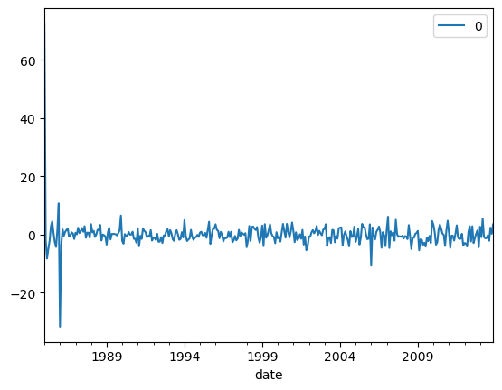

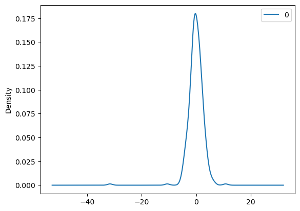

```python
residuals = pd.DataFrame(modelo_final_fit.resid)
residuals.plot()
residuals.iloc[10:,:].plot(kind='kde')
print(residuals.describe())
```

Y, como comprobamos en evaluar_sarima(), los residuos no están autocorrelacionados. Esto se debe a que los p-value obtenidos con el test de Ljung-Box son > 0.05

```python
acorr_ljungbox(modelo_final_fit.resid, lags=6)
```

|  | lb_stat | lb_pvalue |
| --- | --- | --- |
| 1 | 0.398125 | 0.528059 |
| 2 | 3.887726 | 0.143150 |
| 3 | 4.196957 | 0.240967 |
| 4 | 4.306100 | 0.366162 |
| 5 | 4.376454 | 0.496582 |
| 6 | 5.070465 | 0.534808 |

Es decir, los residuos son ruido blanco, no tienen dependencia temporal.

Terminamos mostrando una gráfica con los valores reales y la predicción:

```
RMSE: 3.4482578326418616
```

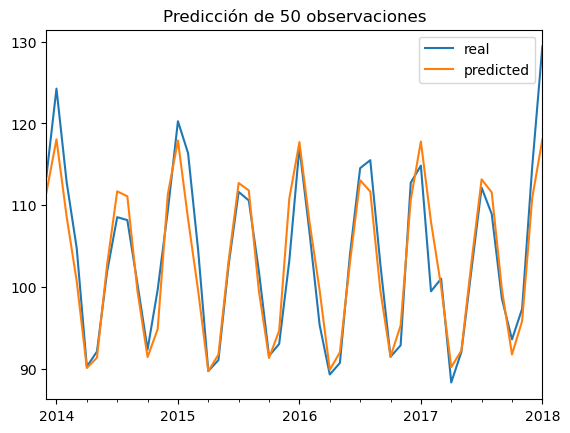

```python
predicted_values = modelo_final_fit.forecast(steps=len(data_test))

rmse = np.sqrt(mean_squared_error(data_test.IPG2211A2N, predicted_values))
print(f'RMSE: {rmse}')
forecasting_data = pd.DataFrame({'real': data_test.IPG2211A2N,'predicted': predicted_values})
forecasting_data.plot(title='Predicción de 50 observaciones')
#pyplot.show()
```